# An Exploration of the Classic Iris Dataset

## by Jared Butler

[figure not shown]

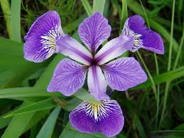

```python
#Common Libraries
import matplotlib.pyplot as plt
from sklearn import datasets
import pandas as pd
```

### This Data Set includes 5 fields in the following indices

1. sepal length in cm
2. sepal width in cm
3. petal length in cm
4. petal width in cm
5. class:
   - Iris Setosa
   - Iris Versicolour
   - Iris Virginica

```
(1.5, 4.9)
```

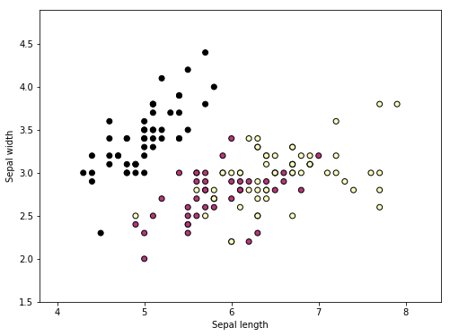

```python
#load sepal data

iris = datasets.load_iris()
sepalx = iris.data[:, :2]
y = iris.target

xmin, xmax = sepalx[:,0].min() - .5, sepalx[:,0].max() + .5
ymin, ymax = sepalx[:,1].min() - .5, sepalx[:,1].max() + .5

plt.figure(2, figsize=(8,6))
plt.clf()

#Plot the training points
plt.scatter(sepalx[:,0], sepalx[:,1], c=y, cmap='magma', edgecolor='k')
plt.xlabel('Sepal length')
plt.ylabel('Sepal width')

plt.xlim(xmin,xmax)
plt.ylim(ymin,ymax)
```

- Black: setosa
- Magenta: versicolor
- Cream: virginica

We can clearly see a distinction between the setosa points from versicolor and viriginica by the ratio between sepal width and sepal length.

Graphically speaking, setosa appears to be linearly separable from the other two species.

However, it is not apparent from this graph how we can distinguish if an unlabeled point is a versicolor or virginica based on the sepal data. Let us look at the petal data to see if we can view a relationship.

```
(-0.4, 3.0)
```

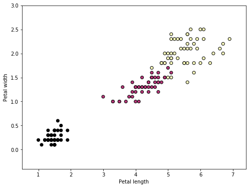

```python
#load sepal data
iris = datasets.load_iris()
petalx = iris.data[:, 2:4]
y = iris.target

xmin, xmax = petalx[:,0].min() - .5, petalx[:,0].max() + .5
ymin, ymax = petalx[:,1].min() - .5, petalx[:,1].max() + .5

plt.figure(2, figsize=(8,6))
plt.clf()

#Plot the training points
plt.scatter(petalx[:,0], petalx[:,1], c=y, cmap='magma', edgecolor='k')
plt.xlabel('Petal length')
plt.ylabel('Petal width')

plt.xlim(xmin,xmax)
plt.ylim(ymin,ymax)
```

- Black: setosa
- Magenta: versicolor
- Cream: virginica

Based on petal length, we can see a clear divide between Setosa and the other two classe. Additionally, we get a much better distinction between versicolor and virginica: virginica appear to have wider and longer petals.

This information is useful in distinguishing between the two, however, the boundary between versicolor and virginica is not clear, so there would be inaccuracy in predicting along the boundary region.